# Statistics with R

Linear Regression

Zhuanghua Shi (Strongway)

25 June, 2019

# Linear regression

- A continuous dependent variable $Y$
- One of more independent variables $X$

We want to estimate their linear relationship:

$$Y = b_0 + b_1 X + \epsilon$$

# An example of linear relationship

- build-in `cars` dataset

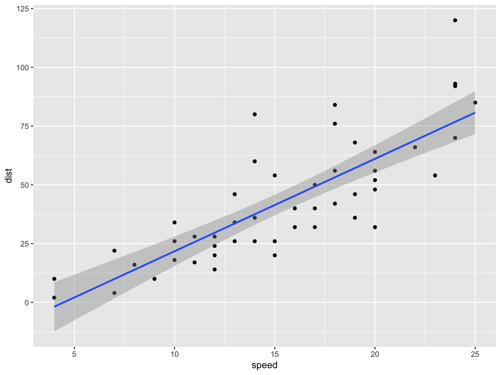

```r
ggplot(cars, aes(speed, dist)) + geom_point() +
  geom_smooth(method = 'lm')
```

# Build linear model

- Linear regression uses function `lm()`
- `lm()` accept
  - formula
  - data

```r
mod1 = lm(dist ~ speed, data = cars)
mod1
```

```
##
## Call:
## lm(formula = dist ~ speed, data = cars)
##
## Coefficients:
## (Intercept)        speed
##     -17.579        3.932
```

# Get model summary

- summary(model) provides residuals, coefficients, statistics, significances, R-squared, F-tests

```r
summary(mod1)
```

```
##
## Call:
## lm(formula = dist ~ speed, data = cars)
##
## Residuals:
##     Min      1Q  Median      3Q     Max
## -29.069  -9.525  -2.272   9.215  43.201
##
## Coefficients:
##             Estimate Std. Error t value Pr(>|t|)
## (Intercept) -17.5791     6.7584  -2.601   0.0123 *
## speed         3.9324     0.4155   9.464 1.49e-12 ***
## ---
## Signif. codes:  0 '***' 0.001 '**' 0.01 '*' 0.05 '.' 0.1 ' ' 1
##
## Residual standard error: 15.38 on 48 degrees of freedom
## Multiple R-squared:  0.6511, Adjusted R-squared:  0.6438
## F-statistic: 89.57 on 1 and 48 DF,  p-value: 1.49e-12
```

# Goodness of fit

- How do we know if the model is good fit?
  - R-Square: higher the better
  - t-statistics: p-value should be less than 0.05

# Prediction of the model

- `predict(model, testData)`
  - note: testData shold contain the IV variables

```r
p_dist = predict(mod1, data.frame(speed = c(20,21)))
print(p_dist)
```

```
##        1        2
## 61.06908 65.00149
```

# R formula

Recall the last session about R formula, and tell the meanings of the following formula.

$$Y \sim X1 + X2 + 1$$
$$Y \sim X1*X2$$

$$Y \sim X1 - 1$$

# Example of model comparison

- Data: Allenmark et al. (2018) Pop-out search Experiment 1

```r
exp1 = read.csv('data/exp1.csv')
mrt = exp1 %>% filter(correct == 1) %>%
  group_by(sub, target, setsize, dyn) %>% summarise(rt = mean(rt))
head(mrt)
```

```
## # A tibble: 6 x 5
## # Groups:   sub, target, setsize [3]
##     sub target setsize dyn        rt
##   <int> <fct>    <int> <fct>   <dbl>
## 1     1 Absent       8 Dynamic  2.57
## 2     1 Absent       8 Static   1.62
## 3     1 Absent      12 Dynamic  3.10
## 4     1 Absent      12 Static   2.05
## 5     1 Absent      16 Dynamic  2.90
## 6     1 Absent      16 Static   2.27
```

# Explore the data

- Explore the relation between the set size and mean reaction time
  - Separate for target Absent / Present, Dynamic / Static

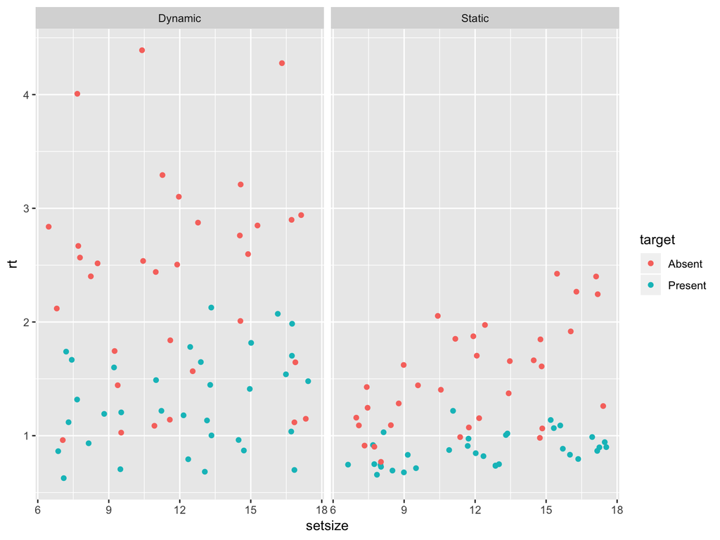

```r
mrt %>% ggplot(aes(setsize, rt, color = target)) + geom_jitter() +
  facet_grid(~dyn)
```

What we saw is that there are linear trends for static condition, but not for dynamic condition.

# Build linear models

- Only main factors

```r
mod1 = lm(rt ~ setsize + target + dyn, data = mrt)
summary(mod1)
```

```
##
## Call:
## lm(formula = rt ~ setsize + target + dyn, data = mrt)
##
## Residuals:
##      Min       1Q   Median       3Q      Max
## -1.31573 -0.32818  0.05824  0.25996  2.12096
##
## Coefficients:
##               Estimate Std. Error t value Pr(>|t|)
## (Intercept)    1.77809    0.19693   9.029 2.24e-15 ***
## setsize        0.04094    0.01484   2.758  0.00667 **
## targetPresent -0.85502    0.09696  -8.818 7.24e-15 ***
## dynStatic     -0.65236    0.09696  -6.728 5.17e-10 ***
## ---
## Signif. codes:  0 '***' 0.001 '**' 0.01 '*' 0.05 '.' 0.1 ' ' 1
##
## Residual standard error: 0.557 on 128 degrees of freedom
## Multiple R-squared:  0.5051, Adjusted R-squared:  0.4935
## F-statistic: 43.54 on 3 and 128 DF,  p-value: < 2.2e-16
```

The above regression suggests the following linear relation:

$$rt = 1.78 + 0.04 \cdot N_{items} - 0.85 \cdot T_p - 0.65 * D_{Static}$$

# Build linear models

- Main factors and two-way interaction

```r
mod2 = lm(rt ~ setsize + target + dyn + setsize:target +
                   setsize:dyn + target:dyn, data = mrt)
summary(mod2)
```

```
##
## Call:
## lm(formula = rt ~ setsize + target + dyn + setsize:target + setsize:dyn +
##     target:dyn, data = mrt)
##
## Residuals:
##      Min       1Q   Median       3Q      Max
## -1.45396 -0.18427  0.00363  0.30203  2.01094
##
## Coefficients:
##                         Estimate Std. Error t value Pr(>|t|)
## (Intercept)              1.80347    0.31884   5.656 9.99e-08 ***
## setsize                  0.04799    0.02535   1.893  0.06064 .
## targetPresent           -0.70919    0.37634  -1.884  0.06183 .
## dynStatic               -1.06899    0.37634  -2.840  0.00526 **
## setsize:targetPresent   -0.03049    0.02927  -1.042  0.29956
## setsize:dynStatic        0.01638    0.02927   0.560  0.57666
## targetPresent:dynStatic  0.44007    0.19118   2.302  0.02300 *
## ---
## Signif. codes:  0 '***' 0.001 '**' 0.01 '*' 0.05 '.' 0.1 ' ' 1
##
## Residual standard error: 0.5491 on 125 degrees of freedom
## Multiple R-squared:  0.5303, Adjusted R-squared:  0.5077
## F-statistic: 23.52 on 6 and 125 DF,  p-value: < 2.2e-16
```

# Compare two models

- Using ANOVA method to compare the two models, with and without the second-order interaction

```r
anova(mod1, mod2)
```

```
## Analysis of Variance Table
##
## Model 1: rt ~ setsize + target + dyn
## Model 2: rt ~ setsize + target + dyn + setsize:target + setsize:dyn +
##     target:dyn
##   Res.Df    RSS Df Sum of Sq      F  Pr(>F)
## 1    128 39.713
## 2    125 37.693  3    2.0194 2.2323 0.08773 .
## ---
## Signif. codes:  0 '***' 0.001 '**' 0.01 '*' 0.05 '.' 0.1 ' ' 1
```

The model comparison suggests that adding the second-order interaction does not make improvement. So we prefer the simple model. Note that there are other models, e.g., the model with main factors and one interaction of target and setsize. You may want to further compare other models as well.

# Remove insig. factor/interaction

- `setsize:dyn` and `setsize:target` are not a critical interactions, shown by the above model. So we remove it.

```r
mod3 = lm(rt ~ setsize + target + dyn +
                    target:dyn, data = mrt)
summary(mod3)
```

```
##
## Call:
## lm(formula = rt ~ setsize + target + dyn + target:dyn, data = mrt)
##
## Residuals:
##      Min       1Q   Median       3Q      Max
## -1.42575 -0.24316  0.01463  0.28416  2.01094
##
## Coefficients:
##                         Estimate Std. Error t value Pr(>|t|)
## (Intercept)              1.88810    0.19947   9.466  < 2e-16 ***
## setsize                  0.04094    0.01460   2.804  0.00584 **
## targetPresent           -1.07506    0.13487  -7.971 7.82e-13 ***
## dynStatic               -0.87240    0.13487  -6.469 1.94e-09 ***
## targetPresent:dynStatic  0.44007    0.19073   2.307  0.02266 *
## ---
## Signif. codes:  0 '***' 0.001 '**' 0.01 '*' 0.05 '.' 0.1 ' ' 1
##
## Residual standard error: 0.5478 on 127 degrees of freedom
## Multiple R-squared:  0.525,  Adjusted R-squared:   0.51
## F-statistic: 35.09 on 4 and 127 DF,  p-value: < 2.2e-16
```

# Compare models

- Compared with and without the interaction ‘target:dyn’
  - Adding the interaction did make difference!

```r
anova(mod1, mod3)
```

```
## Analysis of Variance Table
##
## Model 1: rt ~ setsize + target + dyn
## Model 2: rt ~ setsize + target + dyn + target:dyn
##   Res.Df    RSS Df Sum of Sq      F  Pr(>F)
## 1    128 39.713
## 2    127 38.115  1    1.5977 5.3236 0.02266 *
## ---
## Signif. codes:  0 '***' 0.001 '**' 0.01 '*' 0.05 '.' 0.1 ' ' 1
```

# Visualize the best model

- `lm` method provide direct `plot` for diagnose

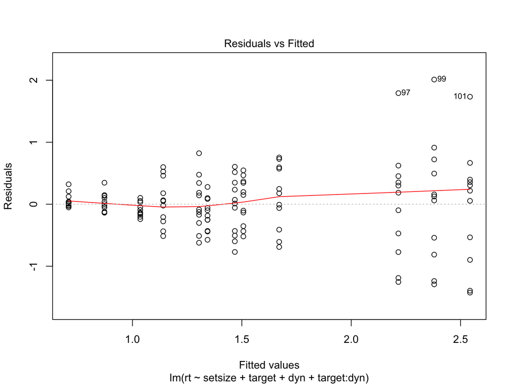

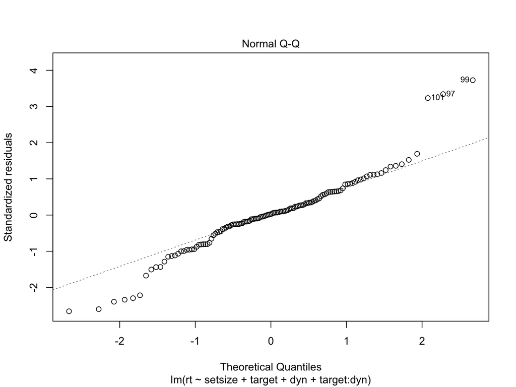

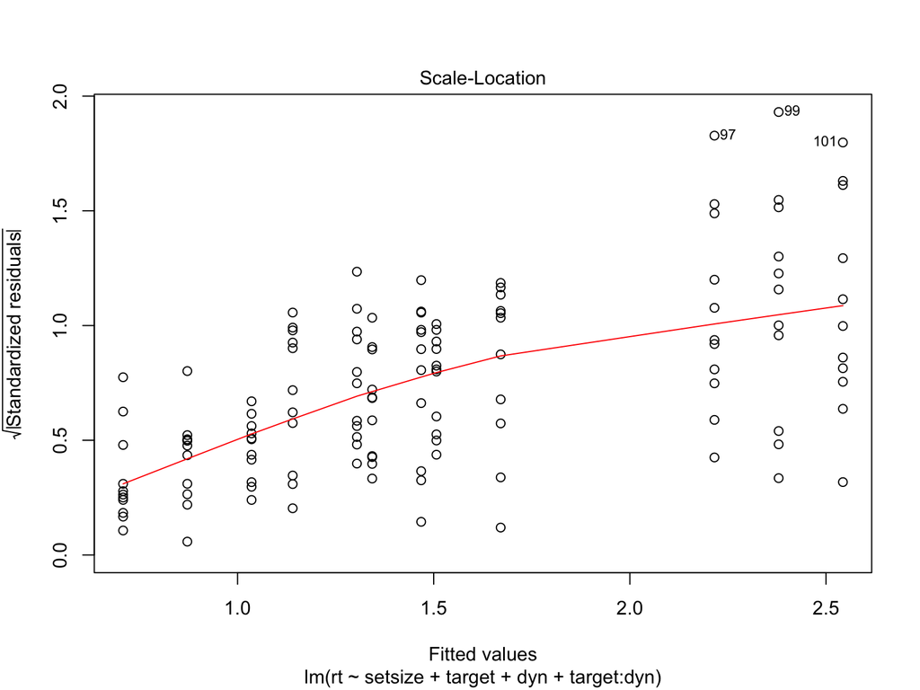

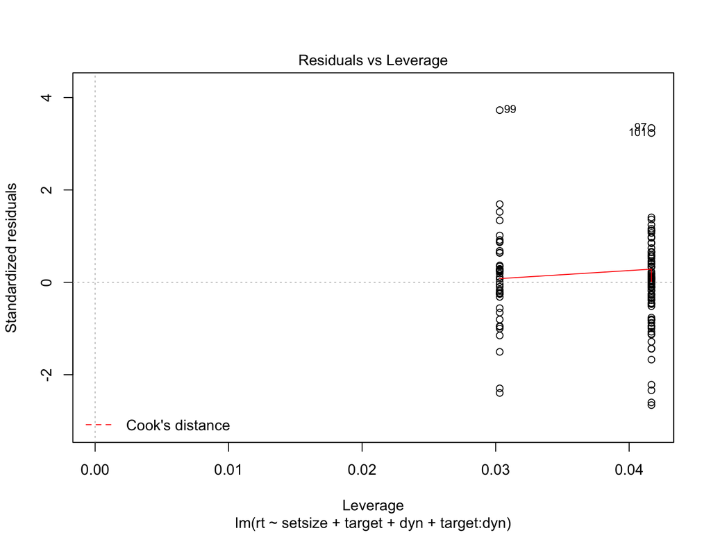

```r
plot(mod3)
```

# Linear model with multiple subsets

The above approach treated all subjects data together. However, we know there are huge between-subject variability. So the better way to do this is to do within-subject linear model.

## A commonn approach

- filter out individual subject data
- do linear regression
- extract linear coefficients
- combined all linear results together into one table

Tidyverse has a better way to integrate the above steps in ‘tidy’ flow.

# Iteraction and Nested table

Iteraction is everywhere. In our previous sections, we use pipe to hide iteraction. For example:

`data %>% group_by(fact1, fact2) %>% summarise(stat1 = mean(var1))`

The above example is actually a two-loop iteraction.

Can we do similar for subset linear modelling?

**Solution**: Nested table

# Nested table

Before we learn how to use multiple linear modelling, we need to understand what a nested table is.

## A nested table

- still a data frame: columns, rows, cells
- but those cells isn’t restricted to numbers, strings or logicals
- the cell itself can be dataframe!

Let’s try nest rt data for each subject.

```r
nested_rt = mrt %>% group_by(sub) %>% nest()
head(nested_rt)
```

```
## # A tibble: 6 x 2
##     sub data
##   <int> <list>
## 1     1 <tibble [12 × 4]>
## 2     2 <tibble [12 × 4]>
## 3     3 <tibble [12 × 4]>
## 4     4 <tibble [12 × 4]>
## 5     5 <tibble [12 × 4]>
## 6     6 <tibble [12 × 4]>
```

The above table has one column called ‘data’, which contains `<tibble>` format cells.

## see the tibble cell

let’s see what subject 1 contains in `data`.

```r
nested_rt$data[[1]]
```

```
## # A tibble: 12 x 4
##    target  setsize dyn        rt
##    <fct>     <int> <fct>   <dbl>
##  1 Absent        8 Dynamic  2.57
##  2 Absent        8 Static   1.62
##  3 Absent       12 Dynamic  3.10
##  4 Absent       12 Static   2.05
##  5 Absent       16 Dynamic  2.90
##  6 Absent       16 Static   2.27
##  7 Present       8 Dynamic  1.12
##  8 Present       8 Static   1.03
##  9 Present      12 Dynamic  1.22
## 10 Present      12 Static   1.22
## 11 Present      16 Dynamic  1.54
## 12 Present      16 Static   1.14
```

It contains the mean rts for the first subject! So what we can do is to submit the `data` cell for linear modelling.

# Linear model

In order to use nested table, we first need to build a function, which does the linear model. That is easy, simply reuse the above code and put them in a function.

```r
lmod <- function(df){
  lmfit = lm(rt ~ setsize + target + dyn + target:dyn, data = df)
  return(lmfit)
}
```

We then check if the above function is correct.

```r
mod_sub1 = lmod(nested_rt$data[[1]])
summary(mod_sub1)
```

```
##
## Call:
## lm(formula = rt ~ setsize + target + dyn + target:dyn, data = df)
##
## Residuals:
##      Min       1Q   Median       3Q      Max
## -0.17908 -0.11195  0.03677  0.08944  0.24613
##
## Coefficients:
##                         Estimate Std. Error t value Pr(>|t|)
## (Intercept)              2.29099    0.20051  11.426 8.83e-06 ***
## setsize                  0.04705    0.01468   3.206 0.014941 *
## targetPresent           -1.56339    0.13557 -11.532 8.30e-06 ***
## dynStatic               -0.87491    0.13557  -6.454 0.000349 ***
## targetPresent:dynStatic  0.71163    0.19172   3.712 0.007537 **
## ---
## Signif. codes:  0 '***' 0.001 '**' 0.01 '*' 0.05 '.' 0.1 ' ' 1
##
## Residual standard error: 0.166 on 7 degrees of freedom
## Multiple R-squared:  0.968,  Adjusted R-squared:  0.9498
## F-statistic: 53.02 on 4 and 7 DF,  p-value: 2.559e-05
```

# The map() function

The map() function transform their input by applying a functionn to each element and returning a vector the same length as the input.

We can use map() to apply linear model for each subject `data` element.

```r
nested_rt %>% mutate(model = map(data, lmod)) -> rt_models
head(rt_models)
```

```
## # A tibble: 6 x 3
##     sub data              model
##   <int> <list>            <list>
## 1     1 <tibble [12 × 4]> <S3: lm>
## 2     2 <tibble [12 × 4]> <S3: lm>
## 3     3 <tibble [12 × 4]> <S3: lm>
## 4     4 <tibble [12 × 4]> <S3: lm>
## 5     5 <tibble [12 × 4]> <S3: lm>
## 6     6 <tibble [12 × 4]> <S3: lm>
```

The return is a model list variable, which is also nested in the result. Let’s see what we get in the cell.

```r
rt_models$model[[1]]
```

```
##
## Call:
## lm(formula = rt ~ setsize + target + dyn + target:dyn, data = df)
##
## Coefficients:
##             (Intercept)                  setsize            targetPresent
##                 2.29099                  0.04705                 -1.56339
##               dynStatic  targetPresent:dynStatic
##                -0.87491                  0.71163
```

# Linear model return coefficients

What we really want is the coefficients from the linear model. So we need to tidy a bit of the results

```r
nested_rt %>% mutate(model = map(data, lmod), result = map(model, tidy)) -> rt_models
head(rt_models)
```

```
## # A tibble: 6 x 4
##     sub data              model    result
##   <int> <list>            <list>   <list>
## 1     1 <tibble [12 × 4]> <S3: lm> <data.frame [5 × 5]>
## 2     2 <tibble [12 × 4]> <S3: lm> <data.frame [5 × 5]>
## 3     3 <tibble [12 × 4]> <S3: lm> <data.frame [5 × 5]>
## 4     4 <tibble [12 × 4]> <S3: lm> <data.frame [5 × 5]>
## 5     5 <tibble [12 × 4]> <S3: lm> <data.frame [5 × 5]>
## 6     6 <tibble [12 × 4]> <S3: lm> <data.frame [5 × 5]>
```

We have now the results, but still need to read them out. This can be done by `unnest()` function.

```r
rt_models %>%
  unnest(result, .drop = TRUE) -> rt_coef
head(rt_coef)
```

```
## # A tibble: 6 x 6
##     sub term                    estimate std.error statistic     p.value
##   <int> <chr>                      <dbl>     <dbl>     <dbl>       <dbl>
## 1     1 (Intercept)               2.29      0.201      11.4  0.00000883
## 2     1 setsize                   0.0470    0.0147      3.21 0.0149
## 3     1 targetPresent            -1.56      0.136     -11.5  0.00000830
## 4     1 dynStatic                -0.875     0.136      -6.45 0.000349
## 5     1 targetPresent:dynStatic   0.712     0.192       3.71 0.00754
## 6     2 (Intercept)               2.00      0.116      17.2  0.000000543
```

# Visualize the slopes

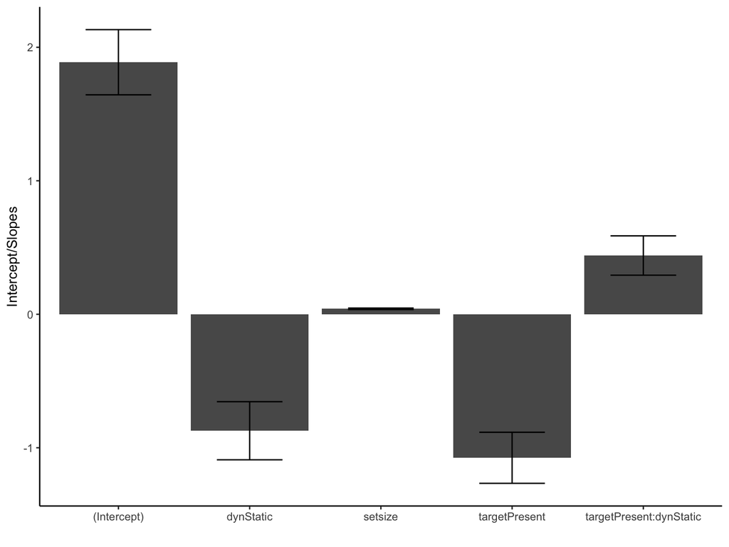

```r
rt_coef %>% group_by(term) %>% summarise(b = mean(estimate), n = n(), se = sd(estimate)/sqrt(n-1)) ->
  mean_coef

mean_coef %>% ggplot(aes(term, b, ymin = b - se, ymax = b + se)) + geom_bar(stat = 'identity') +
  geom_errorbar(width = 0.5) + xlab('') + ylab('Intercept/Slopes') + theme_classic()
```

# References

Some contents from this session are from:

1. Knoblauch & Maloney, Modeling Psychophysical Data in R, 2012
2. An introduction to statiscal and Data Science via R, Moderndive.com
3. R for Data Science (https://r4ds.had.co.nz)